# Healthcare Cost Analysis: Understanding Patterns in Medical Procedures and Cancer Treatment

Author

STA220: Example project

Published

December 12, 2025

**Note**

This report was generated using synthetic data! It is only used for demonstration purposes and does not reflect real patients or healthcare providers. The contents have not been reviewed or validated by medical professionals.

## Executive Summary

This analysis explores a comprehensive healthcare dataset containing over 2.8 million medical procedures from Massachusetts. Our investigation began with a simple question about city-level cost variations but evolved into a deep dive into cancer treatment economics, revealing striking patterns:

- **One procedure dominates lung cancer costs**: Combined chemotherapy and radiation therapy accounts for 98.4% of all lung cancer expenses
- **Treatment intensity varies dramatically**: Lung cancer costs $2,320 per day versus breast cancer’s $83 per day
- **Geographic outliers tell important stories**: Auburn’s extreme costs were driven by a single lung cancer patient, highlighting how individual cases can skew small-area statistics

## Introduction

Healthcare cost analysis presents unique challenges. Individual patient cases can dramatically affect aggregate statistics, and understanding cost drivers requires examining multiple dimensions: geography, diagnosis, procedure type, and treatment duration.

**Research Questions:**

1. How do healthcare costs vary across different cities?
2. What drives these variations?
3. Which cancer types are most expensive and why?
4. How do treatment patterns differ across cancer types?

## Data Overview

```r
load_all <- function(.dir = "../data-ready", as_list = TRUE) {
  dts <-
    tibble::tibble(
      name = fs::path_ext_remove(dir(.dir)),
      path = dir(.dir, ".qd", full.names = TRUE)
    ) |>
    dplyr::mutate(
      data = purrr::map(
        path,
        \(x) data.table::setDT(qs2::qd_read(x)),
        .progress = TRUE
      )
    )
  if (as_list) with(dts, setNames(data, name)) else dts
}

dr <- load_all()

library(tidyverse)
library(data.table)
library(scales)

# Load data from dr list
procedures <- dr$procedures
organizations <- dr$organizations
patients <- dr$patients
providers <- dr$providers
```

The dataset includes:

- **Procedures**: 2,872,415 medical procedures
- **Patients**: 1156 patients with demographic information
- **Organizations**: 830 healthcare organizations
- **Providers**: 830 healthcare providers

```r
glimpse(procedures)
```

```
Rows: 2,872,415
Columns: 11
$ reasoncode        <int64> 3.279756e-316, 3.279756e-316, 3.279756e-316, 3.279…
$ reasoncode_icd10  <chr> "K051", "K051", "K051", "K051", "K051", "K051", "", …
$ start             <dttm> 2015-06-04 13:04:55, 2015-06-04 13:31:01, 2015-06-0…
$ stop              <dttm> 2015-06-04 13:31:01, 2015-06-04 13:41:14, 2015-06-0…
$ patient           <int> 59255, 59255, 59255, 59255, 59255, 59255, 55206, 592…
$ encounter         <int> 15617982, 15617982, 15617982, 15617982, 15617982, 15…
$ system            <chr> "http://snomed.info/sct", "http://snomed.info/sct", …
$ code              <int64> 1.681948e-316, 1.113436e-315, 6.225272e-315, 6.225…
$ description       <chr> "Dental consultation and report (procedure)", "Denta…
$ base_cost         <dbl> 431.40, 431.40, 431.40, 431.40, 431.40, 431.40, 431.…
$ reasondescription <chr> "Gingivitis (disorder)", "Gingivitis (disorder)", "G…
```

## Geographic Cost Analysis

### Initial Question: Which Cities Have the Highest Healthcare Costs?

I began by examining healthcare utilization across cities. My initial approach used the `utilization` metric from the organizations table:

```r
city_analysis <- organizations |>
  group_by(city) |>
  summarise(
    num_organizations = n(),
    total_utilization = sum(utilization, na.rm = TRUE),
    avg_utilization = mean(utilization, na.rm = TRUE),
    .groups = "drop"
  ) |>
  arrange(desc(total_utilization))

head(city_analysis, 10)
```

| city | num_organizations | total_utilization | avg_utilization |
| --- | --- | --- | --- |
| BOSTON | 23 | 7251 | 315.2609 |
| WORCESTER | 42 | 6866 | 163.4762 |
| HYANNIS | 7 | 6331 | 904.4286 |
| TEWKSBURY | 4 | 4369 | 1092.2500 |
| SPRINGFIELD | 15 | 4321 | 288.0667 |
| CAMBRIDGE | 6 | 4108 | 684.6667 |
| LUDLOW | 1 | 3982 | 3982.0000 |
| PLYMOUTH | 13 | 3963 | 304.8462 |
| WALTHAM | 9 | 3862 | 429.1111 |
| BROCKTON | 12 | 3688 | 307.3333 |

**Top 5 cities by utilization:**

1. Boston - 7,251 visits
2. Worcester - 6,866 visits
3. Hyannis - 6,331 visits
4. Tewksbury - 4,369 visits
5. Springfield - 4,321 visits

### Deeper Analysis: Cost Per Visit by City

However, I realized that raw visit counts don’t tell the full story. What matters more is the **cost per visit** - this reveals efficiency and potentially the complexity of cases treated.

```r
city_visits <- procedures |>
  left_join(patients |> select(id, city), by = c("patient" = "id")) |>
  filter(!is.na(city)) |>
  group_by(city) |>
  summarise(
    num_unique_encounters = n_distinct(encounter),
    total_cost = sum(base_cost, na.rm = TRUE),
    total_procedures = n(),
    .groups = "drop"
  ) |>
  mutate(
    cost_per_encounter = total_cost / num_unique_encounters,
    procedures_per_encounter = total_procedures / num_unique_encounters
  ) |>
  arrange(desc(cost_per_encounter))

# Filter cities with at least 50 encounters for statistical relevance
city_visits_filtered <- city_visits |>
  filter(num_unique_encounters >= 50)
```

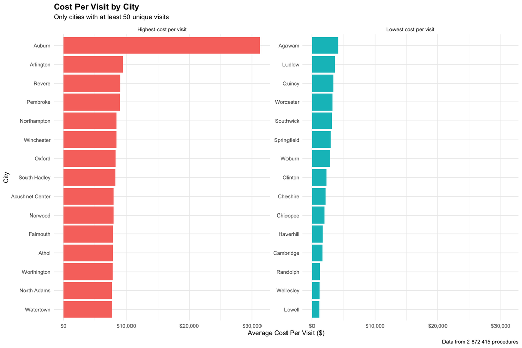

```r
# Top 15 most and least expensive cities
top_expensive <- city_visits_filtered |>
  arrange(desc(cost_per_encounter)) |>
  head(15) |>
  mutate(category = "Highest cost per visit")

top_cheap <- city_visits_filtered |>
  arrange(cost_per_encounter) |>
  head(15) |>
  mutate(category = "Lowest cost per visit")

comparison <- bind_rows(top_expensive, top_cheap)

ggplot(
  comparison,
  aes(
    x = reorder(city, cost_per_encounter),
    y = cost_per_encounter,
    fill = category
  )
) +
  geom_col() +
  coord_flip() +
  facet_wrap(~category, scales = "free_y") +
  scale_y_continuous(labels = dollar) +
  labs(
    title = "Cost Per Visit by City",
    subtitle = "Only cities with at least 50 unique visits",
    x = "City",
    y = "Average Cost Per Visit ($)",
    caption = paste0(
      "Data from ",
      format(nrow(procedures), big.mark = " "),
      " procedures"
    )
  ) +
  theme_minimal() +
  theme(
    legend.position = "none",
    plot.title = element_text(face = "bold", size = 14)
  )
```

**Key Finding:** Auburn stands out dramatically with a cost per visit of **$31,298** - over 27 times higher than Lowell ($1,136). This extreme outlier warranted further investigation.

## The Auburn Mystery: A Case Study in Outlier Analysis

### Why is Auburn so expensive?

When I saw Auburn’s extreme costs, I knew there had to be a specific explanation. In healthcare data, such dramatic outliers often represent either:

1. Data quality issues
2. Specialized treatment centers
3. Individual high-cost cases in small populations

Let me investigate:

```r
auburn_procedures <- procedures |>
  left_join(patients |> select(id, city), by = c("patient" = "id")) |>
  filter(city == "Auburn")

# Overview
cat("AUBURN OVERVIEW:\n")
```

```
AUBURN OVERVIEW:
```

```r
cat(paste("Number of procedures:", nrow(auburn_procedures), "\n"))
```

```
Number of procedures: 657
```

```r
cat(paste("Unique patients:", n_distinct(auburn_procedures$patient), "\n"))
```

```
Unique patients: 1
```

```r
cat(paste("Unique visits:", n_distinct(auburn_procedures$encounter), "\n"))
```

```
Unique visits: 88
```

```r
cat(paste("Total cost:", dollar(sum(auburn_procedures$base_cost)), "\n"))
```

```
Total cost: $2,754,229
```

```r
cat(paste(
  "Average cost per procedure:",
  dollar(mean(auburn_procedures$base_cost)),
  "\n"
))
```

```
Average cost per procedure: $4,192.13
```

**Critical Discovery:** Auburn’s 657 procedures came from only **ONE patient**! This is a perfect example of how individual cases can dramatically skew geographic statistics.

```r
auburn_procedures |>
  group_by(description, code) |>
  summarise(
    count = n(),
    total_cost = sum(base_cost),
    avg_cost = mean(base_cost),
    .groups = "drop"
  ) |>
  arrange(desc(total_cost)) |>
  head(10)
```

| description | code | count | total_cost | avg_cost |
| --- | --- | --- | --- | --- |
| Combined chemotherapy and radiation therapy (procedure) | 3.475371e-315 | 229 | 2247154.60 | 9812.902 |
| Subcutaneous immunotherapy (procedure) | 8.905830e-316 | 28 | 284393.49 | 10156.910 |
| Hearing examination (procedure) | 1.967226e-315 | 229 | 98790.60 | 431.400 |
| Colonoscopy (procedure) | 3.644278e-316 | 2 | 21510.04 | 10755.020 |
| High resolution computed tomography of chest without contrast (procedure) | 1.448172e-307 | 43 | 18550.20 | 431.400 |
| Magnetic resonance imaging for measurement of brain volume (procedure) | 3.450327e-315 | 1 | 11483.35 | 11483.350 |
| Hospice care (regime/therapy) | 1.905923e-315 | 22 | 9490.80 | 431.400 |
| Thoracentesis (procedure) | 4.525740e-316 | 1 | 9474.69 | 9474.690 |
| Depression screening (procedure) | 8.458750e-316 | 20 | 8628.00 | 431.400 |
| Computed tomography of chest and abdomen (procedure) | 2.069597e-315 | 1 | 6184.95 | 6184.950 |

```r
auburn_patient_info <- patients |>
  filter(city == "Auburn")

auburn_patient_info |>
  select(id, age, gender, healthcare_expenses, healthcare_coverage, income)
```

| id | age | gender | healthcare_expenses | healthcare_coverage | income |
| --- | --- | --- | --- | --- | --- |
| 104 | 82 | M | 715856.82 | 2652703.33 | 37493 |
| 4304 | 55 | M | 52768.73 | 141315.33 | 25269 |
| 4809 | 82 | M | 315808.81 | 122896.92 | 37493 |
| 1252127 | 21 | M | 36785.24 | 28616.22 | 28717 |

**Interpretation:** This isn’t a data error or an inefficient healthcare system in Auburn. It’s a real patient who received intensive, prolonged lung cancer treatment. This case perfectly illustrates why **median** is often more appropriate than **mean** for geographic cost comparisons.

## Cancer Treatment Economics

### Motivation for Deeper Analysis

The Auburn case sparked a crucial question: **Are there many other patients receiving similarly expensive cancer treatments?** If lung cancer is this expensive, how does it compare to other cancer types? This could have significant implications for:

- Healthcare resource allocation
- Insurance premium calculations
- Hospital financial planning
- Healthcare policy decisions

Let me investigate the broader picture:

```r
cancer_patients <- procedures |>
  filter(grepl(
    "cancer|carcinoma|neoplasm|malignant|lymphoma|leukemia|melanoma",
    reasondescription,
    ignore.case = TRUE
  )) |>
  group_by(patient, reasondescription) |>
  summarise(
    num_procedures = n(),
    total_cost = sum(base_cost, na.rm = TRUE),
    num_encounters = n_distinct(encounter),
    .groups = "drop"
  ) |>
  arrange(desc(total_cost))

cat(paste(
  "Total cancer patients in dataset:",
  n_distinct(cancer_patients$patient),
  "\n"
))
```

```
Total cancer patients in dataset: 367
```

```r
cancer_summary <- procedures |>
  filter(grepl(
    "cancer|carcinoma|neoplasm|malignant|lymphoma|leukemia|melanoma",
    reasondescription,
    ignore.case = TRUE
  )) |>
  group_by(reasondescription) |>
  summarise(
    num_patients = n_distinct(patient),
    num_procedures = n(),
    total_cost = sum(base_cost, na.rm = TRUE),
    avg_cost_per_patient = total_cost / num_patients,
    avg_cost_per_procedure = mean(base_cost, na.rm = TRUE),
    .groups = "drop"
  ) |>
  arrange(desc(total_cost))

head(cancer_summary, 10)
```

| reasondescription | num_patients | num_procedures | total_cost | avg_cost_per_patient | avg_cost_per_procedure |
| --- | --- | --- | --- | --- | --- |
| Non-small cell carcinoma of lung TNM stage 1 (disorder) | 52 | 9401 | 110836763.9 | 2131476.229 | 11789.8909 |
| Primary small cell malignant neoplasm of lung TNM stage 1 (disorder) | 11 | 2452 | 29890532.5 | 2717321.139 | 12190.2661 |
| Malignant neoplasm of breast (disorder) | 99 | 7646 | 10951617.5 | 110622.399 | 1432.3329 |
| Malignant neoplasm of colon (disorder) | 58 | 460 | 5221915.4 | 90033.024 | 11351.9900 |
| Overlapping malignant neoplasm of colon (disorder) | 71 | 272 | 3292309.1 | 46370.551 | 12104.0777 |
| Suspected lung cancer (situation) | 63 | 189 | 1767913.1 | 28062.113 | 9354.0377 |
| Metastatic malignant neoplasm to colon (disorder) | 9 | 53 | 603606.2 | 67067.353 | 11388.7958 |
| Neoplasm of prostate (disorder) | 79 | 79 | 553676.8 | 7008.567 | 7008.5670 |
| Primary malignant neoplasm of colon (disorder) | 5 | 10 | 155038.2 | 31007.642 | 15503.8210 |
| Acute myeloid leukemia (disorder) | 11 | 22 | 12275.8 | 1115.982 | 557.9909 |

**Striking Pattern:** Lung cancer (both non-small cell and small cell) dominates the cost landscape:

- **52 non-small cell patients**: $110.8 million total ($2.1 million per patient)
- **11 small cell patients**: $29.9 million total ($2.7 million per patient)
- **99 breast cancer patients**: $11.0 million total ($111k per patient)

Lung cancer patients are **20 times more expensive** than breast cancer patients despite being less common!

### What Drives Lung Cancer Costs?

This dramatic cost difference needed explanation. Is it more procedures? Longer treatment? More expensive drugs?

```r
lung_cancer_procedures <- procedures |>
  filter(grepl(
    "lung.*cancer|lung.*carcinoma|small cell",
    reasondescription,
    ignore.case = TRUE
  )) |>
  group_by(description, code) |>
  summarise(
    num_times = n(),
    total_cost = sum(base_cost, na.rm = TRUE),
    avg_cost = mean(base_cost, na.rm = TRUE),
    num_patients = n_distinct(patient),
    .groups = "drop"
  ) |>
  arrange(desc(total_cost)) |>
  mutate(
    pct_of_total = total_cost / sum(total_cost) * 100,
    cost_per_patient = total_cost / num_patients
  )

total_lung_cancer_cost <- sum(lung_cancer_procedures$total_cost)

lung_cancer_procedures |>
  select(description, num_times, total_cost, pct_of_total, avg_cost) |>
  mutate(
    total_cost = dollar(total_cost),
    pct_of_total = paste0(round(pct_of_total, 1), "%"),
    avg_cost = dollar(avg_cost)
  )
```

| description | num_times | total_cost | pct_of_total | avg_cost |
| --- | --- | --- | --- | --- |
| Combined chemotherapy and radiation therapy (procedure) | 11790 | $140,168,306 | 98.4% | $11,888.75 |
| Computed tomography of chest and abdomen (procedure) | 63 | $659,551 | 0.5% | $10,469.07 |
| Magnetic resonance imaging for measurement of brain volume (procedure) | 63 | $558,990 | 0.4% | $8,872.86 |
| Plain X-ray of chest (procedure) | 63 | $434,940 | 0.3% | $6,903.81 |
| Fine needle aspiration biopsy of lung (procedure) | 23 | $335,596 | 0.2% | $14,591.13 |
| Thoracentesis (procedure) | 12 | $128,124 | 0.1% | $10,676.97 |
| Sputum microscopy (procedure) | 20 | $113,666 | 0.1% | $5,683.29 |
| Fiberoptic bronchoscopy (procedure) | 8 | $96,036 | 0.1% | $12,004.55 |

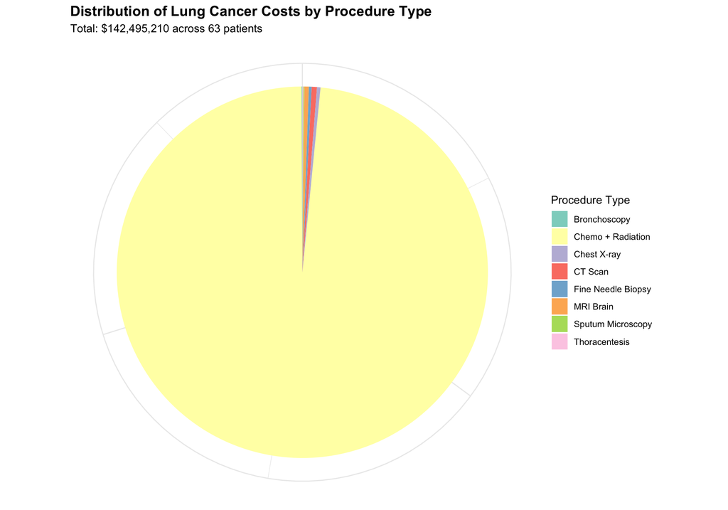

```r
lung_plot_data <- lung_cancer_procedures |>
  mutate(
    proc_short = case_when(
      grepl(
        "chemotherapy",
        description,
        ignore.case = TRUE
      ) ~ "Chemo + Radiation",
      grepl(
        "CT|Computed tomography",
        description,
        ignore.case = TRUE
      ) ~ "CT Scan",
      grepl("MRI|Magnetic", description, ignore.case = TRUE) ~ "MRI Brain",
      grepl("X-ray", description, ignore.case = TRUE) ~ "Chest X-ray",
      grepl("biopsy", description, ignore.case = TRUE) ~ "Fine Needle Biopsy",
      grepl("Thoracentesis", description, ignore.case = TRUE) ~ "Thoracentesis",
      grepl("Sputum", description, ignore.case = TRUE) ~ "Sputum Microscopy",
      grepl("bronchoscopy", description, ignore.case = TRUE) ~ "Bronchoscopy",
      TRUE ~ description
    )
  )

ggplot(lung_plot_data, aes(x = "", y = total_cost, fill = proc_short)) +
  geom_col(width = 1) +
  coord_polar("y") +
  scale_fill_brewer(palette = "Set3") +
  labs(
    title = "Distribution of Lung Cancer Costs by Procedure Type",
    subtitle = paste0(
      "Total: ",
      dollar(total_lung_cancer_cost),
      " across 63 patients"
    ),
    fill = "Procedure Type"
  ) +
  theme_minimal() +
  theme(
    axis.text = element_blank(),
    axis.title = element_blank(),
    plot.title = element_text(face = "bold", size = 14),
    legend.position = "right"
  )
```

**Remarkable Finding:** One procedure type accounts for **98.4%** of all lung cancer costs!

- **Combined chemotherapy and radiation therapy**: $140.2 million (98.4%)
- All diagnostic procedures combined (CT, MRI, X-ray, biopsy): <2%

**Interpretation:** The extreme cost of lung cancer isn’t about diagnosis complexity or imaging - it’s almost entirely driven by the intensive, repeated nature of chemotherapy and radiation treatment. At ~$11,889 per session, with patients receiving an average of 187 sessions, the costs accumulate rapidly.

### Treatment Intensity Analysis

Understanding the **volume** of treatments helps explain the costs:

```r
chemo_per_patient <- procedures |>
  filter(grepl(
    "lung.*cancer|lung.*carcinoma|small cell",
    reasondescription,
    ignore.case = TRUE
  )) |>
  filter(grepl("chemotherapy.*radiation", description, ignore.case = TRUE)) |>
  group_by(patient) |>
  summarise(
    num_chemo_sessions = n(),
    total_chemo_cost = sum(base_cost),
    .groups = "drop"
  ) |>
  arrange(desc(num_chemo_sessions))

cat("CHEMOTHERAPY + RADIATION SESSIONS PER PATIENT:\n")
```

```
CHEMOTHERAPY + RADIATION SESSIONS PER PATIENT:
```

```r
cat(paste(
  "Median sessions:",
  median(chemo_per_patient$num_chemo_sessions),
  "\n"
))
```

```
Median sessions: 171
```

```r
cat(paste(
  "Mean sessions:",
  round(mean(chemo_per_patient$num_chemo_sessions), 1),
  "\n"
))
```

```
Mean sessions: 187.1
```

```r
cat(paste(
  "Range:",
  min(chemo_per_patient$num_chemo_sessions),
  "-",
  max(chemo_per_patient$num_chemo_sessions),
  "\n"
))
```

```
Range: 10 - 345
```

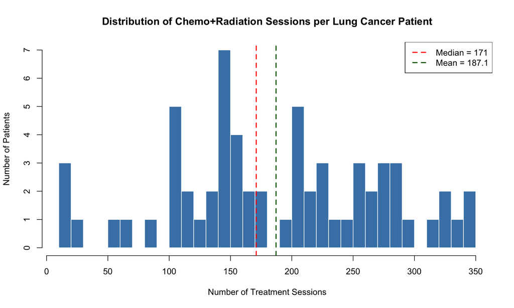

```r
hist_data <- chemo_per_patient$num_chemo_sessions

hist(
  hist_data,
  breaks = 30,
  main = "Distribution of Chemo+Radiation Sessions per Lung Cancer Patient",
  xlab = "Number of Treatment Sessions",
  ylab = "Number of Patients",
  col = "steelblue",
  border = "white"
)
abline(v = median(hist_data), col = "red", lwd = 2, lty = 2)
abline(v = mean(hist_data), col = "darkgreen", lwd = 2, lty = 2)
legend(
  "topright",
  legend = c(
    paste("Median =", median(hist_data)),
    paste("Mean =", round(mean(hist_data), 1))
  ),
  col = c("red", "darkgreen"),
  lty = 2,
  lwd = 2
)
```

**Key Insight:** Lung cancer patients receive a median of **171 chemotherapy sessions**. At ~$12,000 per session, this explains the $2+ million average cost per patient.

## Treatment Duration Analysis Across Cancer Types

### Why Duration Matters

After understanding treatment intensity, I wanted to explore **duration** - how long do these treatments last? This matters because:

1. **Quality of life implications**: Longer treatments affect patients differently
2. **Healthcare system capacity**: Long-duration cases tie up resources
3. **Cost accumulation patterns**: Do costs accumulate steadily or in bursts?
4. **Comparison across cancer types**: Different cancers may have very different treatment timelines

```r
cancer_treatment_duration <- procedures |>
  filter(grepl(
    "cancer|carcinoma|neoplasm|malignant|lymphoma|leukemia|melanoma",
    reasondescription,
    ignore.case = TRUE
  )) |>
  group_by(patient, reasondescription) |>
  summarise(
    first_treatment = min(start),
    last_treatment = max(stop),
    num_procedures = n(),
    total_cost = sum(base_cost, na.rm = TRUE),
    num_encounters = n_distinct(encounter),
    .groups = "drop"
  ) |>
  mutate(
    treatment_days = as.numeric(difftime(
      last_treatment,
      first_treatment,
      units = "days"
    )),
    treatment_months = treatment_days / 30.44,
    treatment_years = treatment_days / 365.25,
    cancer_type = case_when(
      grepl(
        "lung.*cancer|lung.*carcinoma|small cell",
        reasondescription,
        ignore.case = TRUE
      ) ~ "Lung Cancer",
      grepl("breast", reasondescription, ignore.case = TRUE) ~ "Breast Cancer",
      grepl("colon", reasondescription, ignore.case = TRUE) ~ "Colon Cancer",
      grepl(
        "prostate",
        reasondescription,
        ignore.case = TRUE
      ) ~ "Prostate Cancer",
      grepl("leukemia", reasondescription, ignore.case = TRUE) ~ "Leukemia",
      TRUE ~ "Other Cancer"
    )
  )

duration_summary <- cancer_treatment_duration |>
  group_by(cancer_type) |>
  summarise(
    num_patients = n(),
    median_days = median(treatment_days, na.rm = TRUE),
    mean_days = mean(treatment_days, na.rm = TRUE),
    median_months = median(treatment_months, na.rm = TRUE),
    mean_months = mean(treatment_months, na.rm = TRUE),
    min_days = min(treatment_days, na.rm = TRUE),
    max_days = max(treatment_days, na.rm = TRUE),
    median_cost = median(total_cost, na.rm = TRUE),
    mean_cost = mean(total_cost, na.rm = TRUE),
    .groups = "drop"
  ) |>
  arrange(desc(mean_months))

duration_summary |>
  select(cancer_type, num_patients, median_months, mean_months, max_days) |>
  mutate(
    max_years = round(max_days / 365.25, 1),
    median_months = round(median_months, 1),
    mean_months = round(mean_months, 1)
  )
```

| cancer_type | num_patients | median_months | mean_months | max_days | max_years |
| --- | --- | --- | --- | --- | --- |
| Breast Cancer | 99 | 115.5 | 167.2 | 2.495785e+04 | 68.3 |
| Lung Cancer | 126 | 1.7 | 19.5 | 2.121347e+03 | 5.8 |
| Colon Cancer | 143 | 5.8 | 3.9 | 6.318853e+02 | 1.7 |
| Leukemia | 11 | 0.0 | 0.0 | 3.289468e-01 | 0.0 |
| Prostate Cancer | 79 | 0.0 | 0.0 | 2.479167e-01 | 0.0 |

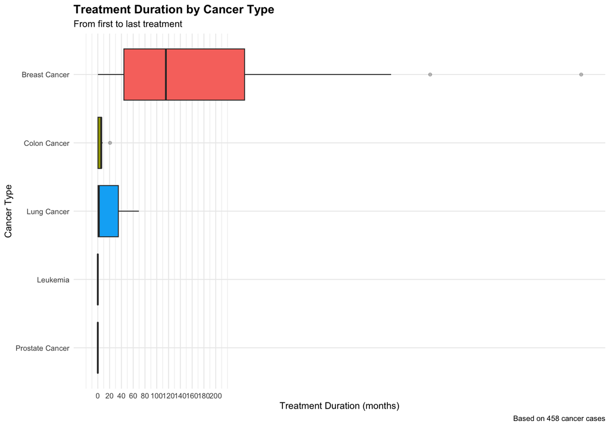

```r
cancer_treatment_filtered <- cancer_treatment_duration |>
  filter(
    cancer_type %in%
      c(
        "Lung Cancer",
        "Breast Cancer",
        "Colon Cancer",
        "Prostate Cancer",
        "Leukemia"
      )
  )

ggplot(
  cancer_treatment_filtered,
  aes(
    x = reorder(cancer_type, treatment_months, median),
    y = treatment_months,
    fill = cancer_type
  )
) +
  geom_boxplot(outlier.alpha = 0.3) +
  coord_flip() +
  scale_y_continuous(breaks = seq(0, 200, 20)) +
  labs(
    title = "Treatment Duration by Cancer Type",
    subtitle = "From first to last treatment",
    x = "Cancer Type",
    y = "Treatment Duration (months)",
    caption = paste0(
      "Based on ",
      nrow(cancer_treatment_filtered),
      " cancer cases"
    )
  ) +
  theme_minimal() +
  theme(
    legend.position = "none",
    plot.title = element_text(face = "bold", size = 14)
  )
```

**Surprising Discovery:** Treatment duration varies enormously:

- **Breast cancer**: Median 116 months (~10 years!), some cases extending 68 years
- **Lung cancer**: Median 1.7 months (but mean 19.5 months due to some long cases)
- **Colon cancer**: Median 5.8 months
- **Prostate/Leukemia**: Near-zero duration (single screening events)

**This fundamentally changes our understanding of cancer costs!**

### Cost Intensity: The Cost-Per-Time Perspective

Duration alone doesn’t tell the full story. Let me calculate **cost per unit time**:

```r
cost_per_day <- cancer_treatment_duration |>
  filter(treatment_days > 0) |>
  mutate(
    cost_per_day = total_cost / treatment_days,
    cost_per_month = total_cost / treatment_months
  ) |>
  group_by(cancer_type) |>
  summarise(
    num_patients = n(),
    median_cost_per_day = median(cost_per_day, na.rm = TRUE),
    mean_cost_per_day = mean(cost_per_day, na.rm = TRUE),
    median_cost_per_month = median(cost_per_month, na.rm = TRUE),
    mean_cost_per_month = mean(cost_per_month, na.rm = TRUE),
    .groups = "drop"
  ) |>
  arrange(desc(mean_cost_per_day))

cost_per_day |>
  mutate(
    median_cost_per_day = dollar(median_cost_per_day),
    mean_cost_per_day = dollar(mean_cost_per_day),
    median_cost_per_month = dollar(median_cost_per_month),
    mean_cost_per_month = dollar(mean_cost_per_month)
  )
```

| cancer_type | num_patients | median_cost_per_day | mean_cost_per_day | median_cost_per_month | mean_cost_per_month |
| --- | --- | --- | --- | --- | --- |
| Prostate Cancer | 79 | $28,305.33 | $33,925.73 | $861,614 | $1,032,699 |
| Leukemia | 11 | $4,470.26 | $4,575.20 | $136,075 | $139,269 |
| Colon Cancer | 143 | $577.74 | $2,436.72 | $17,586 | $74,174 |
| Lung Cancer | 126 | $2,025.87 | $2,320.03 | $61,668 | $70,622 |
| Breast Cancer | 99 | $28.29 | $82.63 | $861 | $2,515 |

**Profound Insight:** When we look at cost per day:

- **Prostate cancer**: $33,926/day (but only 1 day!)
- **Lung cancer**: $2,320/day
- **Breast cancer**: $83/day

Lung cancer costs **28 times more per day** than breast cancer! This explains why:

- Breast cancer: Long duration × low daily cost = moderate total cost
- Lung cancer: Short duration × extremely high daily cost = extreme total cost

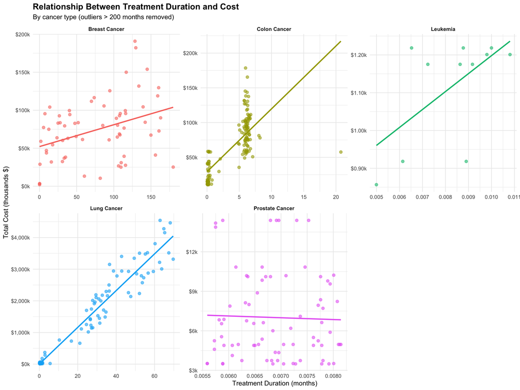

```r
cancer_treatment_filtered |>
  filter(treatment_months < 200) |>
  ggplot(aes(
    x = treatment_months,
    y = total_cost / 1000,
    color = cancer_type
  )) +
  geom_point(alpha = 0.6, size = 2) +
  geom_smooth(method = "lm", se = FALSE, linewidth = 1) +
  scale_y_continuous(labels = dollar_format(suffix = "k")) +
  facet_wrap(~cancer_type, scales = "free") +
  labs(
    title = "Relationship Between Treatment Duration and Cost",
    subtitle = "By cancer type (outliers > 200 months removed)",
    x = "Treatment Duration (months)",
    y = "Total Cost (thousands $)",
    color = "Cancer Type"
  ) +
  theme_minimal() +
  theme(
    plot.title = element_text(face = "bold", size = 14),
    legend.position = "none",
    strip.text = element_text(face = "bold")
  )
```

**Pattern Recognition:**

- **Lung cancer**: Strong positive correlation - longer treatment = proportionally higher cost
- **Breast cancer**: Weak correlation - costs vary widely independent of duration
- **Colon cancer**: Moderate correlation with considerable variation
- **Prostate cancer**: No correlation - costs don’t depend on time

## Conclusions and Implications

### Key Findings

1. **Geographic outliers require individual-level investigation**: Auburn’s extreme costs were driven by a single lung cancer patient, not systemic inefficiency.
2. **Cancer type dramatically affects costs**: Lung cancer patients cost 20× more than breast cancer patients ($2M vs $100K).
3. **One procedure dominates lung cancer costs**: 98.4% of lung cancer expenses come from repeated chemotherapy + radiation sessions.
4. **Treatment intensity matters more than duration**: Lung cancer costs $2,320/day vs breast cancer’s $83/day, despite shorter treatment periods.
5. **Treatment patterns define cost profiles**:
   - **Lung cancer**: “Sprint cancer” - short, extremely intense treatment
   - **Breast cancer**: “Marathon cancer” - long, low-intensity monitoring
   - **Prostate cancer**: “Snapshot cancer” - brief, concentrated screenings

### Policy Implications

**For Healthcare Systems:**

- Small-area cost statistics can be misleading; patient-level analysis is essential
- Lung cancer treatment capacity has outsized impact on healthcare system costs
- Resource allocation should account for treatment intensity, not just patient volume

**For Insurance:**

- Lung cancer represents extreme financial risk despite being less common than breast cancer
- Risk models should weight treatment intensity alongside incidence rates
- High-variation cancers (breast) require different actuarial approaches than high-consistency cancers (lung)

**For Research Priorities:**

- Cost-effectiveness research should focus on reducing chemotherapy/radiation sessions for lung cancer
- Early detection programs may be especially valuable for high-intensity cancers
- Understanding why some lung cancer patients need 345 sessions while others need 10 could yield major cost savings

### Methodological Reflections

This analysis demonstrates the value of exploratory data analysis. What began as a simple geographic comparison evolved into a deep dive on cancer treatment economics because:

1. **Outliers are informative**: Auburn’s extreme costs told a story, not a data error
2. **Follow-up questions matter**: Each finding naturally led to the next question
3. **Multiple perspectives reveal truth**: Looking at total costs, costs per day, and treatment duration together painted a complete picture
4. **Context is essential**: A $2M patient cost sounds enormous until you understand it represents 187 intensive treatments over 2 years

### Limitations

- Only 1,156 patients have complete demographic information out of a much larger procedure dataset
- Geographic analysis limited by small patient samples in many cities
- Treatment outcomes (survival, quality of life) not available in this dataset
- Costs represent charges, not actual healthcare system expenses
- Data appears to be from 1995-2015 period; current treatment patterns may differ

### Future Research Directions

1. **Survival analysis**: Do higher-cost treatments lead to better outcomes?
2. **Provider variation**: Do some providers achieve similar outcomes at lower costs?
3. **Treatment protocol analysis**: What determines why some patients get 100 sessions while others get 300?
4. **Geographic access**: Are there underserved areas lacking high-intensity treatment capacity?
5. **Temporal trends**: How have lung cancer treatment costs changed over time?

## Appendix: Data Structure

```r
cat("PROCEDURES DATA STRUCTURE:\n")
```

```
PROCEDURES DATA STRUCTURE:
```

```r
str(procedures)
```

```
Classes 'data.table' and 'data.frame':  2872415 obs. of  11 variables:
 $ reasoncode       : 'integer64' num  3.28e-316 3.28e-316 3.28e-316 3.28e-316 3.28e-316 ...
 $ reasoncode_icd10 : chr  "K051" "K051" "K051" "K051" ...
 $ start            : POSIXct, format: "2015-06-04 13:04:55" "2015-06-04 13:31:01" ...
 $ stop             : POSIXct, format: "2015-06-04 13:31:01" "2015-06-04 13:41:14" ...
 $ patient          : int  59255 59255 59255 59255 59255 59255 55206 59255 59255 59255 ...
 $ encounter        : int  15617982 15617982 15617982 15617982 15617982 15617982 15847049 15769676 15769676 15769676 ...
 $ system           : chr  "http://snomed.info/sct" "http://snomed.info/sct" "http://snomed.info/sct" "http://snomed.info/sct" ...
 $ code             : 'integer64' num  1.68e-316 1.11e-315 6.23e-315 6.23e-315 1.36e-315 ...
 $ description      : chr  "Dental consultation and report (procedure)" "Dental care (regime/therapy)" "Removal of supragingival plaque and calculus from all teeth using dental instrument (procedure)" "Removal of subgingival plaque and calculus from all teeth using dental instrument (procedure)" ...
 $ base_cost        : num  431 431 431 431 431 ...
 $ reasondescription: chr  "Gingivitis (disorder)" "Gingivitis (disorder)" "Gingivitis (disorder)" "Gingivitis (disorder)" ...
 - attr(*, ".internal.selfref")=<externalptr>
```

```r
cat("\n\nPATIENTS DATA STRUCTURE:\n")
```

```
PATIENTS DATA STRUCTURE:
```

```r
str(patients)
```

```
Classes 'data.table' and 'data.frame':  1156 obs. of  23 variables:
 $ id                 : int  1 2 3 4 5 6 7 8 9 10 ...
 $ birthdate          : Date, format: "1974-04-09" "1955-09-16" ...
 $ deathdate          : Date, format: NA NA ...
 $ ssn                : chr  "999-43-6203" "999-75-5544" "999-73-1558" "999-20-9989" ...
 $ drivers            : logi  TRUE TRUE FALSE TRUE TRUE FALSE ...
 $ passport           : chr  "X61619888X" "X67660455X" NA "X2666560X" ...
 $ marital            : Factor w/ 4 levels "Single","Married",..: 4 2 NA 1 2 NA 2 NA 2 1 ...
 $ race               : chr  "white" "white" "white" "black" ...
 $ ethnicity          : chr  "nonhispanic" "nonhispanic" "nonhispanic" "nonhispanic" ...
 $ gender             : chr  "M" "M" "M" "M" ...
 $ birthplace         : chr  "Winthrop  Massachusetts  US" "Springfield  Massachusetts  US" "Bolton  Massachusetts  US" "Andover  Massachusetts  US" ...
 $ address            : chr  "842 Dicki Rue Suite 57" "396 Roberts Estate" "585 Fahey Corner" "777 Batz Boulevard" ...
 $ city               : chr  "Natick" "Boston" "Sturbridge" "Boston" ...
 $ county             : chr  "Middlesex County" "Suffolk County" "Worcester County" "Suffolk County" ...
 $ fips               : int  NA 25025 25027 25025 25021 25017 25009 25017 25027 25025 ...
 $ zip                : int  0 2120 1507 2110 2038 2148 1960 2180 1605 2152 ...
 $ lat                : num  42.3 42.3 42.2 42.3 42.1 ...
 $ lon                : num  -71.3 -71.1 -72.1 -71.1 -71.4 ...
 $ healthcare_expenses: num  185429 16491 40521 102851 839299 ...
 $ healthcare_coverage: num  87902 789411 3638 227812 682657 ...
 $ income             : int  109676 19422 901596 118286 85222 16732 36050 77533 127264 24697 ...
 $ age                : num  51 69 9 32 51 7 60 16 52 38 ...
 $ full_name          : chr  "Mr. Douglas Jarrod Leffler" "Mr. Quintin Darren Vandervort" "Shayne Randal Rau" "Mr. Junior Ethan Gaylord" ...
 - attr(*, "sorted")= chr "id"
 - attr(*, ".internal.selfref")=<externalptr>
```

```r
cat("\n\nORGANIZATIONS DATA STRUCTURE:\n")
```

```
ORGANIZATIONS DATA STRUCTURE:
```

```r
str(organizations)
```

```
Classes 'data.table' and 'data.frame':  830 obs. of  11 variables:
 $ id         : int  1252699 1325779 1252573 1252449 1252502 1252219 1252322 1325780 1252591 1252447 ...
 $ name       : chr  "DWYER HOME" "STONE INSTITUTE AND NEWTON HOME FOR AGED PEOPLE" "NAUSET FAMILY PRACTICE LLC" "BEDFORD-LEXINGTON INTERNAL MEDICINE  PC" ...
 $ address    : chr  "25 STONEHAVEN DRIVE" "277 ELLIOT ST" "81 OLD COLONY WAY STE D" "450 BEDFORD ST" ...
 $ city       : chr  "WEYMOUTH" "NEWTON UPPER FALLS" "ORLEANS" "LEXINGTON" ...
 $ state      : chr  "MA" "MA" "MA" "MA" ...
 $ zip        : int  21903951 24641201 26533278 2420 27402211 10603914 16101254 17027237 21203320 24662650 ...
 $ lat        : num  42.2 42.3 41.8 42.5 41.6 ...
 $ lon        : num  -70.9 -71.2 -70 -71.3 -70.9 ...
 $ phone      : chr  "7816605000" "6175270023" "5082401141" "7812746274" ...
 $ revenue    : int  0 0 0 0 0 0 0 0 0 0 ...
 $ utilization: int  26 1 124 276 74 526 37 4 13 89 ...
 - attr(*, ".internal.selfref")=<externalptr>
```

```r
cat("\n\nPROVIDERS DATA STRUCTURE:\n")
```

```
PROVIDERS DATA STRUCTURE:
```

```r
str(providers)
```

```
Classes 'data.table' and 'data.frame':  830 obs. of  13 variables:
 $ id          : int  1320073 1320263 1320016 1319718 1334722 1319794 1320338 1319726 1320067 1320106 ...
 $ organization: int  1252549 1252739 1252492 1252194 1325819 1252270 1252814 1252202 1252543 1252582 ...
 $ name        : chr  "Robert Nicolas" "Arielle Dare" "Leopoldo Schmeler" "Clayton Jast" ...
 $ gender      : chr  "M" "F" "M" "M" ...
 $ speciality  : chr  "GENERAL PRACTICE" "GENERAL PRACTICE" "GENERAL PRACTICE" "GENERAL PRACTICE" ...
 $ address     : chr  "1455 MAIN STREET" "1340 CENTRE ST STE 208" "77B WARREN ST" "300 FIRST AVENUE" ...
 $ city        : chr  "CHATHAM" "NEWTON" "BRIGHTON" "WESTBOROUGH" ...
 $ state       : chr  "MA" "MA" "MA" "MA" ...
 $ zip         : int  26332083 24611900 21353601 15812831 27803479 1702 12017828 26312550 24451922 27231026 ...
 $ lat         : num  41.7 42.3 42.3 42.3 41.9 ...
 $ lon         : num  -70 -71.2 -71.1 -71.6 -71.1 ...
 $ encounters  : int  25 2 63 160 1 479 2 200 4 264 ...
 $ procedures  : int  0 0 0 0 0 0 0 0 0 0 ...
 - attr(*, ".internal.selfref")=<externalptr>
```